# Markup Solutions Exercise 1

Daniel Anadria

15 September 2022

**Exercise 1: Git and Monte Carlo simulation with a GitHub flavor**

In this exercise, I sample 100 samples from a normal distribution with the mean $\mu = 100$ and the standard deviation $\sigma = 15$.. For each of the samples, I calculate the following statistics for the mean:

- absolute bias
- standard error
- lower bound of the 95% confidence interval
- upper bound of the 95% confidence interval

Finally, I plot the resulting 95% confidence intervals.

```r
# defining population values
population <- new.env()
population$mean <- 100
population$sd <- 15
as.list(population)

# 100 samples of 1000 observations from the population
set.seed(123) # for reproducibility
samples <- data.frame(matrix(ncol = 100, nrow = 1000))
for (i in 1:100){
  samples[,i] <- rnorm(n = 1000, mean = 100, sd = 15)}
```

Computing the sample means:

```r
samplemeans <- data.frame(matrix(ncol = 100, nrow = 1))
for (i in 1:100){
  samplemeans[,i] <- mean(samples[,i])}
```

Computing the absolute bias for each sample:

```r
absolutebias <- data.frame(matrix(ncol = 100, nrow = 1))
for (i in 1:100){
  absolutebias[,i] <- abs(population$mean - samplemeans[,i])}
```

Computing the standard errorfor each sample:

```r
# SD of every sample
sampleSDs <- data.frame(matrix(ncol = 100, nrow = 1))
for (i in 1:100){
  sampleSDs[,i] <- sd(samples[,i])}

# SE of every sample
sampleSEs <- data.frame(matrix(ncol = 100, nrow = 1))
for (i in 1:100){
  sampleSEs[,i] <- sampleSDs[,i] / sqrt(nrow(samples))}
```

95% confidence interval for each sample:

```r
# lower bound
CIlower <- data.frame(matrix(ncol = 100, nrow = 1))
for (i in 1:100){
  CIlower[,i] <- samplemeans[,i] - 1.959964 * sampleSEs[,i]}

# upper bound
CIupper <- data.frame(matrix(ncol = 100, nrow = 1))
for (i in 1:100){
  CIupper[,i] <- samplemeans[,i] + 1.959964 * sampleSEs[,i]}
```

Preparing the data for `ggplot2`:

```r
library(tidyverse)
```

```r
data <- data.frame(sample_id = 1:100, lower_bound = t(CIlower), sample_mean = t(samplemeans), upper_bound = t(CIupper), row.names = 1:100)

data$sample_biased <- ifelse((data$upper_bound < 100) | (data$lower_bound > 100), "Yes", "No")

data_long <- data %>% pivot_longer(c(2,4), names_to = "Statistic", values_to = "Values")
```

Plotting the 95% confidence interval for each sample:

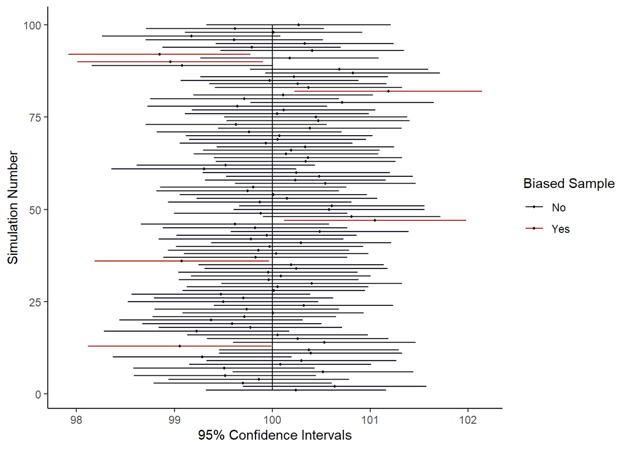

```r
ggplot(data_long, aes(x = Values, y = sample_id)) +
   geom_line(aes(colour = sample_biased, group = sample_id)) +
   scale_color_manual(values=c("#00000f", "#a10a02"), name = "Biased Sample", )+
   geom_point(aes(sample_mean), size = 0.75, show.legend = T)+
   geom_line(aes(x = population$mean), linetype = "solid") +
   xlab("95% Confidence Intervals") +
   ylab("Simulation Number")+
   theme_classic()
```

```r
table(data$sample_biased)
```

```
##
##  No Yes
##  94   6
```

In line with the Neyman’s quote, in our simulated data, 6% of confidence intervals did not contain the true population mean. This is close to the expectation of 5% of the 95% confidence intervals will not contain the true population parameter. In an infinitely large sample, this proportion would equal exactly 5%. Here I present a table containing all simulated samples for which the resulting confidence interval does not contain the population mean.

```r
data %>% filter(sample_biased == 'Yes')
```

```
##   sample_id lower_bound sample_mean upper_bound sample_biased
## 1        13    98.11779    99.05426    99.99072           Yes
## 2        36    98.18307    99.07562    99.96817           Yes
## 3        47   100.12143   101.04976   101.97808           Yes
## 4        82   100.22759   101.18583   102.14407           Yes
## 5        90    98.00909    98.95679    99.90449           Yes
## 6        92    97.91532    98.84654    99.77776           Yes
```